# Twitter Troll Project

### Definition of troll

In my definition, Twitter trolls includes two categories:

1. If a person’s tweets often contains swear words.
2. If a person’s tweets often spark many comments that contain swear words. These tweets may not contain curse words, but they are provocative in nature. The comments, which is a large pool, are highly likely to contain swear words.

## Collecting data

### Retrieve user list

First load packages:

```r
library('RCurl')
library('twitteR')
library('readr')
library(dplyr)
library(stringr)
```

```r
setwd('/Users/guanghaoqi/Documents/Adv_data_science/twitter_troll_project')
accounts = read_lines("raw_data/top_twitter_accounts.txt")
accounts = accounts[grepl('@',accounts)]
accounts = gsub('.*@','',accounts)
accounts = gsub('Featured user:','',accounts)
```

### Downloading tweets

Tutorial: R Twitter mining: https://www.youtube.com/watch?v=lT4Kosc_ers. First, get API authorization:

```r
source('twitter_api.R')
setup_twitter_oauth(consumer_key, consumer_secret, access_token, access_secret)
```

```
## [1] "Using direct authentication"
```

Next, search tweets based on the information above. For each account in the top 100 list, request 100 tweets from Twitter. This step was completed in multiple attempts due to API rate limits.

```r
# tweets = vector('list', length = length(accounts))
# acct.search = paste0('from:',accounts)
#
# for (i in 1:length(accounts)){
#     tweets[[i]] = searchTwitter(acct.search[[i]], n = 100, lang = 'en')
# }
# save(tweets, file = 'raw_data/tweets_top100.RData')
```

Different users allow access to different numbers of tweets:

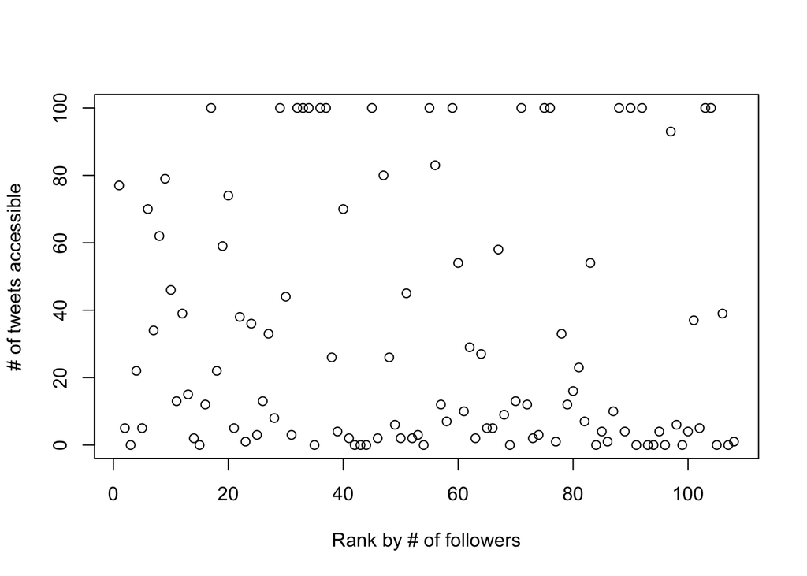

```r
load('raw_data/tweets_top100.RData')
tweet_count = sapply(tweets,length)
plot(1:length(accounts),tweet_count, xlab = 'Rank by # of followers', ylab = '# of tweets accessible')
```

## Methods

1. English swear words list: http://www.youswear.com/index.asp?language=English and http://www.noswearing.com/dictionary. I’m using the latter one because it’s richer. Due to the small number of accessible tweets of some accounts, we may not identify any of the words in a small disctionary. We compute the frequency of swear words in each person’s tweets.

```r
swear = read_lines('raw_data/swearwords.txt')
swear = swear[swear!='']
# Now clean the curse words dictionary swear and save it i vector swear.cl
swear.cl = swear %>% sapply(strsplit, split = ' - ') %>%
    unlist %>% unique
head(swear.cl)
```

```
## [1] "anus"     "butt"     "arse"     "arsehole" "ass"      "ass-hat"
```

Frequency of the swear words: how to retrieve strings from S4 class?